# PSU_MLR

Sam Colon

10/13/2017

```r
data <- read.csv('brain.csv')
head(data)
```

```
##   Gender FSIQ VIQ PIQ Weight Height MRICount
## 1 Female  133 132 124    118   64.5   816932
## 2   Male  140 150 124      *   72.5  1001121
## 3   Male  139 123 150    143   73.3  1038437
## 4   Male  133 129 128    172   68.8   965353
## 5 Female  137 132 134    147   65.0   951545
## 6 Female   99  90 110    146   69.0   928799
```

```r
library(dplyr)
data_subset <- subset(data, select=c('PIQ', 'Weight','Height', 'MRICount'))
```

```r
#remove case with missing data
data_subset <- data_subset[-c(2,21),]
data_subset$MRICount <- data_subset$MRICount/10000 #divide var by 10,000
data_subset$Weight <- as.numeric(data_subset$Weight)
#convert weight from factor to numeric
```

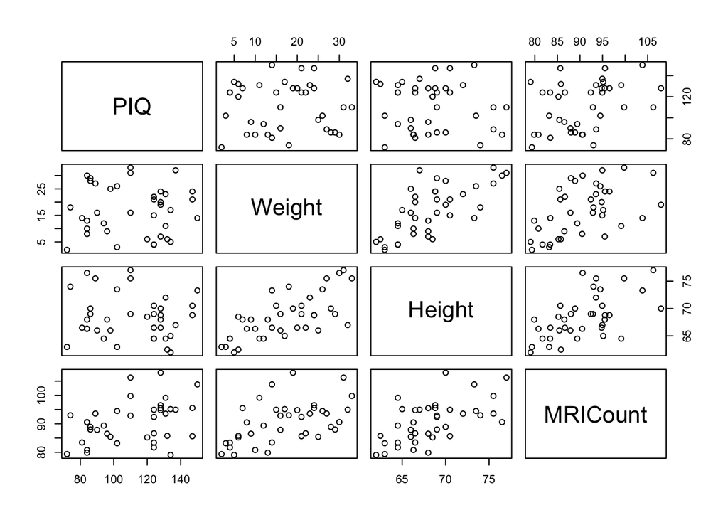

```r
#make scatterplot matrix
pairs(data_subset)
```

### It appears there’s collinearity in the height and weight, although PIQ doesn’t look linearly related to the other variables.

```r
##build multiple reg model for this dataset with PIQ as response variable,
model <- lm(PIQ ~ Weight+Height+MRICount, data=data_subset)
summary(model)
```

```
##
## Call:
## lm(formula = PIQ ~ Weight + Height + MRICount, data = data_subset)
##
## Residuals:
##     Min      1Q  Median      3Q     Max
## -32.840 -12.121  -3.848  14.221  51.730
##
## Coefficients:
##              Estimate Std. Error t value Pr(>|t|)
## (Intercept) 109.70504   74.68680   1.469 0.151061
## Weight       -0.01635    0.50549  -0.032 0.974379
## Height       -2.70728    1.22553  -2.209 0.034009 *
## MRICount      2.06395    0.56443   3.657 0.000856 ***
## ---
## Signif. codes:  0 '***' 0.001 '**' 0.01 '*' 0.05 '.' 0.1 ' ' 1
##
## Residual standard error: 19.79 on 34 degrees of freedom
## Multiple R-squared:  0.2949, Adjusted R-squared:  0.2327
## F-statistic: 4.741 on 3 and 34 DF,  p-value: 0.007218
```

### Baby Bird Dataset

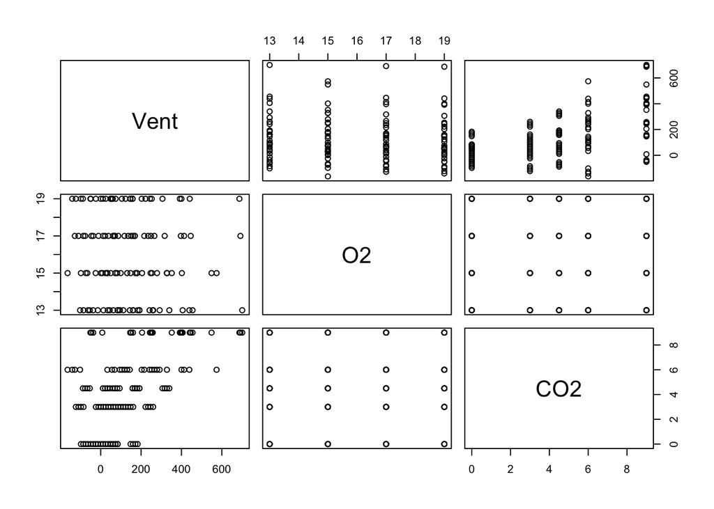

```r
bird_df <- read.table('babybirds.txt', header=TRUE)
pairs(bird_df)
```

```r
bird_model <- lm(Vent ~ O2 + CO2, data=bird_df)
summary(bird_model)
```

```
##
## Call:
## lm(formula = Vent ~ O2 + CO2, data = bird_df)
##
## Residuals:
##     Min      1Q  Median      3Q     Max
## -356.57  -96.50    8.72   84.68  422.44
##
## Coefficients:
##             Estimate Std. Error t value Pr(>|t|)
## (Intercept)   85.901    106.006   0.810    0.419
## O2            -5.330      6.425  -0.830    0.408
## CO2           31.103      4.789   6.495  2.1e-09 ***
## ---
## Signif. codes:  0 '***' 0.001 '**' 0.01 '*' 0.05 '.' 0.1 ' ' 1
##
## Residual standard error: 157.4 on 117 degrees of freedom
## Multiple R-squared:  0.2682, Adjusted R-squared:  0.2557
## F-statistic: 21.44 on 2 and 117 DF,  p-value: 1.169e-08
```

### Soapsuds Example

```r
##soapsuds example, computing regression coefficients
soap_df <- read.table('soapsuds.txt', header=TRUE)
X <- as.matrix(soap_df['soap'])
X <- cbind(c(1,1,1,1,1,1,1),X) #add columns of 1s
XtX <- t(X) %*% X
Y <- soap_df$suds
XtY <- t(X) %*%Y
X_inv <- solve(XtX)
b <- X_inv%*%XtY
print(b)
```

```
##           [,1]
##      -2.678571
## soap  9.500000
```

### So we see the reg equation is suds = -2.68 + 9.500 * soap

### What if we purposely make columns linearly dependent

```r
X2 <- data.frame(X)
X2$soap2 <- (X2$soap)*2
X2 <- as.matrix(X2)
X2tX2 <- t(X2) %*% X2
X2_inv <- solve(X2tX2) #we get error telling us matrix is singular, so inverse not computible.
```

```
## Error in solve.default(X2tX2): Lapack routine dgesv: system is exactly singular: U[3,3] = 0
```

### Pastry Sweetness Dataset: An experiment to assess how moisture content and sweetness of a pastry affects a taster’s ratings of the pastry

```r
pastry_df <- read.csv('pastry.csv', header=TRUE)
pastry_df$Sweetness<- as.factor(pastry_df$Sweetness)
```

### Check correlation of predictor variables

```r
cor(pastry_df$Moisture, as.numeric(pastry_df$Sweetness), method="pearson")
```

```
## [1] 0
```

```r
cor.test(pastry_df$Moisture, as.numeric(pastry_df$Sweetness))
```

```
##
##  Pearson's product-moment correlation
##
## data:  pastry_df$Moisture and as.numeric(pastry_df$Sweetness)
## t = 0, df = 14, p-value = 1
## alternative hypothesis: true correlation is not equal to 0
## 95 percent confidence interval:
##  -0.4957053  0.4957053
## sample estimates:
## cor
##   0
```

### We see 0 correlation.

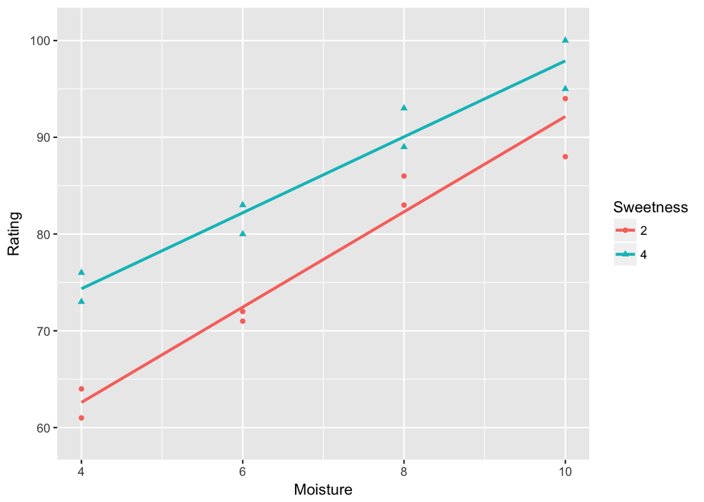

```r
library(ggplot2)
#Plot of Rating vs Moisure w/markers for both levels of sweetness.
ggplot(pastry_df, aes(y = Rating, x= Moisture, colour= Sweetness, shape = Sweetness)) + geom_point() +geom_smooth(method='lm', fill=NA)
```

### Perform Simple and Multiple Regressions on Pastry Data

```r
moisture_model <- lm(Rating~ Moisture, data=pastry_df)
summary(moisture_model)
```

```
##
## Call:
## lm(formula = Rating ~ Moisture, data = pastry_df)
##
## Residuals:
##    Min     1Q Median     3Q    Max
## -7.475 -4.688 -0.100  4.638  7.525
##
## Coefficients:
##             Estimate Std. Error t value Pr(>|t|)
## (Intercept)   50.775      4.395  11.554 1.52e-08 ***
## Moisture       4.425      0.598   7.399 3.36e-06 ***
## ---
## Signif. codes:  0 '***' 0.001 '**' 0.01 '*' 0.05 '.' 0.1 ' ' 1
##
## Residual standard error: 5.349 on 14 degrees of freedom
## Multiple R-squared:  0.7964, Adjusted R-squared:  0.7818
## F-statistic: 54.75 on 1 and 14 DF,  p-value: 3.356e-06
```

```r
anova(moisture_model)
```

```
## Analysis of Variance Table
##
## Response: Rating
##           Df  Sum Sq Mean Sq F value    Pr(>F)
## Moisture   1 1566.45 1566.45  54.751 3.356e-06 ***
## Residuals 14  400.55   28.61
## ---
## Signif. codes:  0 '***' 0.001 '**' 0.01 '*' 0.05 '.' 0.1 ' ' 1
```

```r
pastry_df <- read.csv('pastry.csv', header=TRUE)
sweetness_model <- lm(Rating ~ Sweetness, data = pastry_df)
summary(sweetness_model)
```

```
##
## Call:
## lm(formula = Rating ~ Sweetness, data = pastry_df)
##
## Residuals:
##     Min      1Q  Median      3Q     Max
## -16.375  -7.312  -0.125   8.688  16.625
##
## Coefficients:
##             Estimate Std. Error t value Pr(>|t|)
## (Intercept)   68.625      8.610   7.970 1.43e-06 ***
## Sweetness      4.375      2.723   1.607     0.13
## ---
## Signif. codes:  0 '***' 0.001 '**' 0.01 '*' 0.05 '.' 0.1 ' ' 1
##
## Residual standard error: 10.89 on 14 degrees of freedom
## Multiple R-squared:  0.1557, Adjusted R-squared:  0.09539
## F-statistic: 2.582 on 1 and 14 DF,  p-value: 0.1304
```

```r
anova(sweetness_model)
```

```
## Analysis of Variance Table
##
## Response: Rating
##           Df  Sum Sq Mean Sq F value Pr(>F)
## Sweetness  1  306.25  306.25  2.5817 0.1304
## Residuals 14 1660.75  118.62
```

```r
pastry_df <- read.csv('pastry.csv', header=TRUE)
pastry_mlr <- lm(Rating ~ Moisture + Sweetness, data=pastry_df)
summary(pastry_mlr)
```

```
##
## Call:
## lm(formula = Rating ~ Moisture + Sweetness, data = pastry_df)
##
## Residuals:
##    Min     1Q Median     3Q    Max
## -4.400 -1.762  0.025  1.587  4.200
##
## Coefficients:
##             Estimate Std. Error t value Pr(>|t|)
## (Intercept)  37.6500     2.9961  12.566 1.20e-08 ***
## Moisture      4.4250     0.3011  14.695 1.78e-09 ***
## Sweetness     4.3750     0.6733   6.498 2.01e-05 ***
## ---
## Signif. codes:  0 '***' 0.001 '**' 0.01 '*' 0.05 '.' 0.1 ' ' 1
##
## Residual standard error: 2.693 on 13 degrees of freedom
## Multiple R-squared:  0.9521, Adjusted R-squared:  0.9447
## F-statistic: 129.1 on 2 and 13 DF,  p-value: 2.658e-09
```

```r
anova(pastry_mlr)
```

```
## Analysis of Variance Table
##
## Response: Rating
##           Df  Sum Sq Mean Sq F value    Pr(>F)
## Moisture   1 1566.45 1566.45 215.947 1.778e-09 ***
## Sweetness  1  306.25  306.25  42.219 2.011e-05 ***
## Residuals 13   94.30    7.25
## ---
## Signif. codes:  0 '***' 0.001 '**' 0.01 '*' 0.05 '.' 0.1 ' ' 1
```

### Heart Rabbit Study

```r
rabbit_df <- read.csv('coolhearts.csv', header=TRUE)
rabbit_df$Group <- as.factor(rabbit_df$Group)
## Set Group 3 as reference level
rabbit_df <- within(rabbit_df, Group <-relevel(Group, ref=3))

#Build Reg Model
rabbit_lm <- lm(Infarction ~ factor(Group) + Area, data = rabbit_df)
summary(rabbit_lm)
```

```
##
## Call:
## lm(formula = Infarction ~ factor(Group) + Area, data = rabbit_df)
##
## Residuals:
##      Min       1Q   Median       3Q      Max
## -0.29410 -0.06511 -0.01329  0.07855  0.35949
##
## Coefficients:
##                Estimate Std. Error t value Pr(>|t|)
## (Intercept)    -0.13454    0.10402  -1.293 0.206459
## factor(Group)1 -0.24348    0.06229  -3.909 0.000536 ***
## factor(Group)2 -0.06566    0.06507  -1.009 0.321602
## Area            0.61265    0.10705   5.723 3.87e-06 ***
## ---
## Signif. codes:  0 '***' 0.001 '**' 0.01 '*' 0.05 '.' 0.1 ' ' 1
##
## Residual standard error: 0.1395 on 28 degrees of freedom
## Multiple R-squared:  0.6377, Adjusted R-squared:  0.5989
## F-statistic: 16.43 on 3 and 28 DF,  p-value: 2.363e-06
```

### So, the regression equation is -.135 + .613*Area -.2435X2 - .0657X3

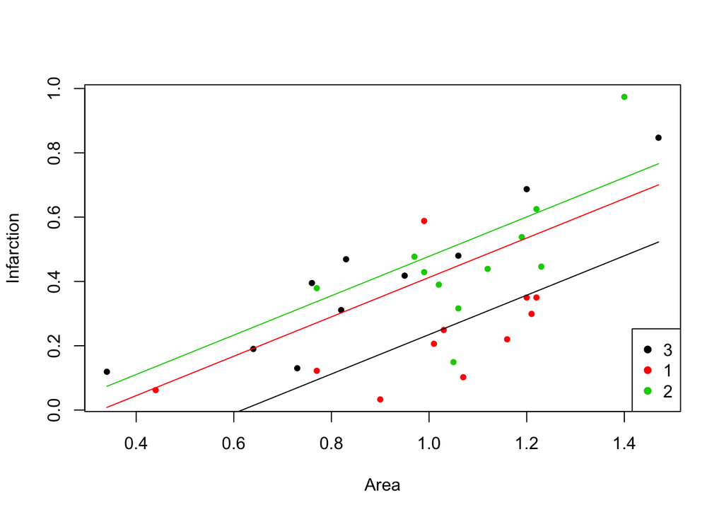

```r
#Plot of Infarction vs Area, with separate regression lines for each group
plot(Infarction~Area,rabbit_df,col=rabbit_df$Group,pch=20)
curve(predict(rabbit_lm,newdata=data.frame(Area=x,Group=1)),col=1,add=T)
curve(predict(rabbit_lm,newdata=data.frame(Area=x,Group=2)),col=2,add=T)
curve(predict(rabbit_lm,newdata=data.frame(Area=x,Group=3)),col=3,add=T)
legend('bottomright', levels(factor(rabbit_df$Group)), pch = 16, col =  which(levels(rabbit_df$Group) %in% levels(factor(rabbit_df$Group))))
```

### So, we see that as risk Area increases, size of Infarction tends to increase.

### Calculating F-stat from regression output:

```r
full_anova <- anova(rabbit_lm) #sum of squares from full model

#reduced model
rabbit_lmr <- lm(Infarction ~ + Area, data = rabbit_df)
reduced_anova <- anova(rabbit_lmr)

#The general F-stat is calculated as (SSE(R)-SSE(F)/df(SSE(R)-df(SSE(F))))/(SSE(F)/df(SSE(F))

F_stat <- (reduced_anova$`Sum Sq`[2] -full_anova$`Sum Sq`[3])/(reduced_anova$Df[2]-full_anova$Df[3])/(full_anova$`Sum Sq`[3]/((full_anova$Df[3])))
F_stat
```

```
## [1] 8.590176
```

### We can explicitly calculate the p-value of this F_stat

```r
pf(F_stat, 2, 28, lower.tail=FALSE)
```

```
## [1] 0.001232872
```

### Therefore, we can conclude that there is a statistically significant relationship between the method of cooling treatment and infarction size.

### We can also compute a partial F-statistic for variables x2 and x3 using sequential sum of squares, where we add x2 and x3 in order, given that x1 is already in the model

```r
rabbit_partialF<- lm(Infarction ~ + Area + X2 + X3 , data = rabbit_df)
anova_partial <- anova(rabbit_partialF)
rabbit_partialF
```

```
##
## Call:
## lm(formula = Infarction ~ +Area + X2 + X3, data = rabbit_df)
##
## Coefficients:
## (Intercept)         Area           X2           X3
##    -0.13454      0.61265     -0.24348     -0.06566
```

```r
anova_partial
```

```
## Analysis of Variance Table
##
## Response: Infarction
##           Df  Sum Sq Mean Sq F value    Pr(>F)
## Area       1 0.62492 0.62492 32.1115 4.504e-06 ***
## X2         1 0.31453 0.31453 16.1622  0.000398 ***
## X3         1 0.01981 0.01981  1.0181  0.321602
## Residuals 28 0.54491 0.01946
## ---
## Signif. codes:  0 '***' 0.001 '**' 0.01 '*' 0.05 '.' 0.1 ' ' 1
```

```r
# The F stat becomes SSR(X2, X3|X1)/(2)/(SSE(X2,X3|28)) or MSR(X2, X3|X1)/MSE(X1,X2,X3)

partial_Fstat<- ((anova_partial$`Sum Sq`[2]+ anova_partial$`Sum Sq`[3])/2)/((anova_partial$`Sum Sq`[4]/28))
partial_Fstat
```

```
## [1] 8.590176
```

### We see the resulting F-stat is the same

### To test if one slope parameter is 0, we can also use the t-test, as the square of the t-stat will equal the F-statistic

```r
#The test for testing area is:
rabbit_lm <- lm(Infarction ~ + Area + X2 + X3 , data = rabbit_df)
full_anova <-anova(rabbit_lm)
Area_Fstat <- (full_anova$`Sum Sq`[1]/full_anova $Df[1])/(full_anova$`Sum Sq`[4]/full_anova$Df[4])
Area_Fstat
```

```
## [1] 32.11154
```

```r
pf(Area_Fstat, 1, 28, lower.tail=FALSE)
```

```
## [1] 4.503703e-06
```

```r
summary <- summary(rabbit_lm)
#Get t-stat for Area and square it
summary$coefficients[2,3] ^2
```

```
## [1] 32.7536
```

```r
#We see it nearly equals F-stat above
```

### Sugar Beet Study

```r
#plot(Infarction~Area,rabbit_df,col=rabbit_df$Group,pch=20)
#curve(predict(rabbit_lm,newdata=data.frame(Area=x,Group=1)),col=1,add=T)

beet_df <-read.csv('beets.csv')
beet_df$Treat <- as.factor(beet_df$Treat)
beet_df <- within(beet_df, Treat <-relevel(Treat, ref=1))
```

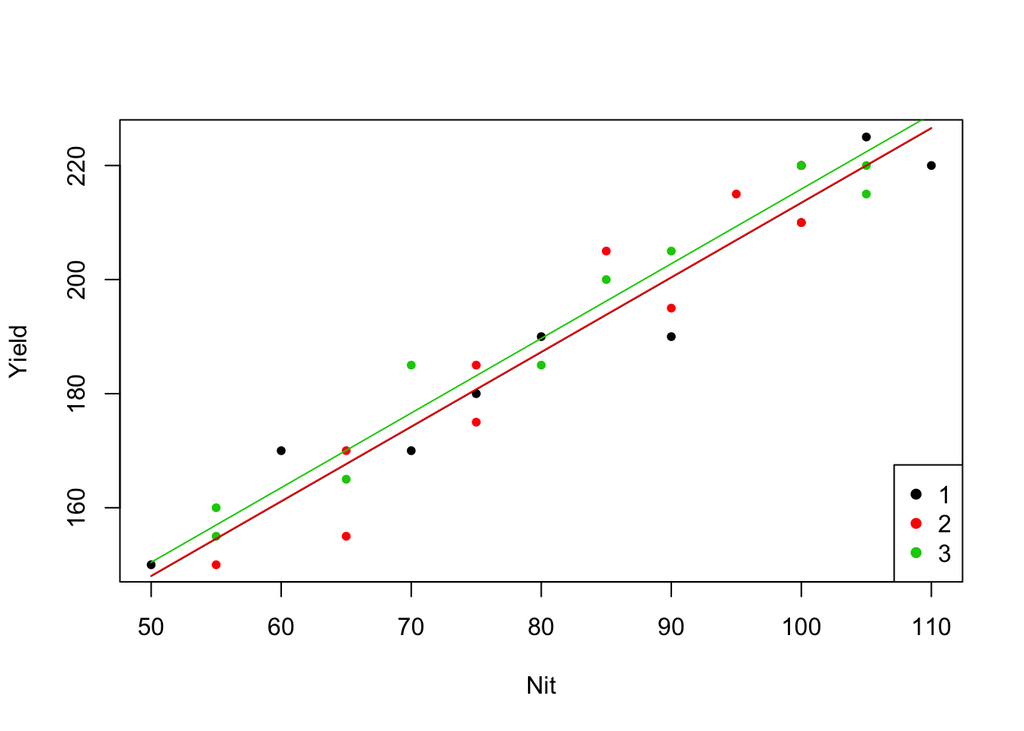

```r
#Regression model
beet_lm <- lm(Yield ~ factor(Treat) + Nit, data = beet_df)


plot(Yield ~ Nit,beet_df,col=beet_df$Treat,pch=20)
curve(predict(beet_lm,newdata=data.frame(Nit=x,Treat=1)),col=1,add=T)
curve(predict(beet_lm,newdata=data.frame(Nit=x,Treat=2)),col=2,add=T)
curve(predict(beet_lm,newdata=data.frame(Nit=x,Treat=3)),col=3,add=T)
legend('bottomright', levels(factor(beet_df$Treat)), pch = 16, col =  which(levels(beet_df$Treat) %in% levels(factor(beet_df$Treat))))
```

### So, we see a clear linear relationship between amount of nitrogen and yield of sugar beets